© Bản quyền thuộc về Quantopian Inc.  
© Bản quyền sửa đổi thuộc về AI Cafe¹  
Giấy phép [Creative Commons Attribution 4.0](https://creativecommons.org/licenses/by/4.0/legalcode).  
[Khuyến cáo](https://aicafe.one/khuyen-cao/)

# Thư viện NumPy

by Maxwell Margenot

Edited by AI Cafe¹

NumPy là một thư viện cực kỳ mạnh mẽ trong Python, được sử dụng rộng rãi trong tài chính định lượng. Nó có sự tích hợp mạnh mẽ với Pandas, một công cụ khác mà chúng ta sẽ đề cập trong chuỗi bài giảng. NumPy bổ sung hỗ trợ cho các mảng đa chiều và các hàm toán học cho phép bạn dễ dàng thực hiện các phép toán đại số tuyến tính. Bài giảng này sẽ là một tập hợp các ví dụ về đại số tuyến tính được tính toán bằng NumPy.

```python
import numpy as np
import matplotlib.pyplot as plt
```

## Mảng dữ liệu trong NumPy

Cách cơ bản nhất mà chúng ta có thể sử dụng NumPy trong tài chính là tính toán tỷ suất sinh lợi trung bình của một danh mục đầu tư. Giả sử chúng ta có một danh sách chứa tỷ suất sinh lợi lịch sử của một số cổ phiếu.

```python
stock_list = [3.5, 5, 2, 8, 4.2]
```

Chúng ta có thể tạo một mảng bằng cách gọi một hàm trên danh sách:

```python
returns = np.array(stock_list)
print(returns, type(returns))
```

```
[3.5 5.  2.  8.  4.2] <class 'numpy.ndarray'>
```

Bạn sẽ nhận thấy rằng kiểu của mảng của chúng ta là 'ndarray', chứ không chỉ là 'array'. Điều này là vì các mảng NumPy có thể được tạo ra với nhiều chiều khác nhau. Nếu chúng ta truyền np.array() một danh sách chứa các danh sách, nó sẽ tạo ra một mảng 2 chiều. Nếu chúng ta truyền một danh sách chứa các danh sách của các danh sách, nó sẽ tạo ra một mảng 3 chiều, và cứ thế tiếp tục.

```python
A = np.array([[1, 2], [3, 4]])
print(A, type(A))
```

```
[[1 2]
 [3 4]] <class 'numpy.ndarray'>
```

Chúng ta có thể truy cập kích thước của một mảng bằng cách xem thuộc tính `shape` của nó.

```python
print(A.shape)
```

```
(2, 2)
```

Mảng được chỉ mục theo cách tương tự như danh sách trong Python. Các phần tử của một danh sách bắt đầu chỉ mục từ $0$ và kết thúc ở $n - 1$, trong đó $n$ là độ dài của mảng.

```python
print(returns[0], returns[len(returns) - 1])
```

```
3.5 4.2
```

Chúng ta có thể lấy một lát cắt (slice) của mảng bằng cách sử dụng dấu hai chấm, giống như trong danh sách.

```python
print(returns[1:3])
```

```
[5. 2.]
```

Một lát của mảng, giống như trong danh sách, sẽ chọn một nhóm các phần tử trong mảng bắt đầu từ phần tử đầu tiên được chỉ định và đi đến (nhưng không bao gồm) phần tử cuối cùng được chỉ định.

Trong trường hợp của các mảng đa chiều, nhiều quy ước tương tự về việc cắt lát và chỉ mục vẫn giữ nguyên. Chúng ta có thể truy cập cột đầu tiên của một mảng 2 chiều như sau:

```python
print(A[:, 0])
```

```
[1 3]
```

Và hàng đầu tiên của một mảng hai chiều như thế này:

```python
print(A[0, :])
```

```
[1 2]
```

Lưu ý rằng mỗi phần của mảng trả về một mảng khác!

```python
print(type(A[0,:]))
```

```
<class 'numpy.ndarray'>
```

Việc chỉ truyền một chỉ số cho một mảng hai chiều sẽ dẫn đến việc trả về hàng với chỉ số đã cho, cung cấp cho chúng ta một cách khác để truy cập các hàng riêng lẻ.

```python
print(A[0])
```

```
[1 2]
```

Truy cập chỉ số của một phần tử riêng lẻ sẽ chỉ trả về phần tử đó.

```python
print(A[1, 1])
```

```
4
```

### Các hàm làm việc với mảng

Các hàm được tích hợp sẵn trong NumPy có thể được gọi dễ dàng trên các mảng. Hầu hết các hàm được áp dụng cho các phần tử của mảng (giống như phép nhân vô hướng). Ví dụ, nếu chúng ta gọi `log()` trên một mảng, logarithm sẽ được tính cho từng phần tử.

```python
print(np.log(returns))
```

```
[1.25276297 1.60943791 0.69314718 2.07944154 1.43508453]
```

Một số hàm trả về một giá trị duy nhất. Điều này xảy ra vì chúng xem mảng như một tập hợp (tương tự như một danh sách), thực hiện chức năng được chỉ định. Ví dụ, hàm `mean()` sẽ làm đúng như bạn mong đợi, tính toán giá trị trung bình của một mảng.

```python
print(np.mean(returns))
```

```
4.54
```

Hoặc hàm `max()` sẽ trả về phần tử lớn nhất của một mảng.

```python
print(np.max(returns))
```

```
8.0
```

Để tìm hiểu thêm về các hàm phổ quát trong NumPy, hãy xem [tài liệu](https://docs.scipy.org/doc/numpy/user/quickstart.html#universal-functions).

## Trở lại với returns

Bây giờ, hãy chỉnh sửa mảng giá trị `returns` của chúng ta bằng các giá trị vô hướng. Nếu chúng ta cộng một giá trị vô hướng vào một mảng, nó sẽ được cộng vào từng phần tử của mảng. Nếu chúng ta nhân một mảng với một giá trị vô hướng, nó sẽ được nhân với từng phần tử của mảng. Nếu chúng ta làm cả hai, cả hai điều đó sẽ xảy ra!

```python
returns*2 + 5
```

```
array([12. , 15. ,  9. , 21. , 13.4])
```

NumPy cũng có các hàm được xây dựng đặc biệt để hoạt động trên các mảng. Hãy tính trung bình và độ lệch chuẩn của nhóm giá trị trả về này.

```python
print("Mean:", np.mean(returns), "Std Dev:", np.std(returns))
```

```
Mean: 4.54 Std Dev: 1.9915822855207364
```

Hãy bắt đầu mô phỏng một tập cổ phiếu bằng cách sử dụng các hàm của NumPy. Đầu tiên, chúng ta cần tạo các mảng để lưu trữ tài sản và lợi nhuận mà chúng ta sẽ sử dụng để xây dựng một danh mục đầu tư. Điều này là vì các mảng được tạo ra với kích thước cố định. Kích thước của chúng không thể thay đổi mà không tạo ra một mảng mới.

```python
N = 10
assets = np.zeros((N, 100))
returns = np.zeros((N, 100))
```

Hàm này, `zeroes()`, tạo ra một mảng NumPy với kích thước được chỉ định và hoàn toàn được lấp đầy bằng $0$. Chúng ta có thể truyền vào một giá trị đơn lẻ hoặc một tuple với nhiều chiều như chúng ta muốn. Việc truyền vào tuple `(N, 100)` sẽ trả về một mảng hai chiều với $N$ hàng và $100$ cột. Kết quả của chúng ta là một mảng $N \times 100$.

Bây giờ, chúng ta sẽ mô phỏng một tài sản cơ sở. Chúng ta muốn tập cổ phiếu có sự tương quan với nhau nên chúng ta sẽ sử dụng giá trị ban đầu này để tạo ra các giá trị khác.

```python
R_1 = np.random.normal(1.01, 0.03, 100)
returns[0] = R_1
assets[0] = np.cumprod(R_1)
```

Module `random` trong NumPy cực kỳ hữu ích. Nó chứa các phương thức để lấy mẫu từ nhiều phân phối xác suất khác nhau, một số trong đó đã được đề cập trong bài giảng về biến ngẫu nhiên. Trong trường hợp này, chúng ta rút ra $N = 100$ mẫu ngẫu nhiên từ một phân phối chuẩn với trung bình là $1.01$ và độ lệch chuẩn là $0.03$. Chúng ta coi những giá trị này là tỷ suất hoàn vốn hàng ngày của tài sản và lấy tích lũy của những mẫu này để có được giá hiện tại.

Cách chúng ta đã tạo ra tập vũ trụ của mình, các vector $R_i$ riêng lẻ là mỗi mảng một chiều và các biến `returns` và `assets` chứa các mảng hai chiều. Ở trên, chúng ta đã thiết lập hàng đầu tiên của cả `returns` và `assets` là vector $R_i$ đầu tiên và giá tài sản tích lũy dựa trên những tỷ suất hoàn vốn đó, tương ứng.

Bây giờ, chúng ta sẽ sử dụng tài sản cơ sở này để tạo ra một vài tài sản ngẫu nhiên khác có sự tương quan với nó.

```python
# Generate assets that are correlated with R_1
for i in range(1, N):
    R_i = R_1 + np.random.normal(0.001, 0.02, 100)
    returns[i] = R_i # Set each row of returns equal to the new R_i array
    assets[i] = np.cumprod(R_i)

mean_returns = [(np.mean(R) - 1)*100 for R in returns]
return_volatilities = [np.std(R) for R in returns]
```

Ở đây, chúng ta tạo ra $N - 1$ chứng khoán còn lại mà chúng ta muốn trong tập vũ trụ của mình bằng cách thêm nhiễu ngẫu nhiên vào $R_1$. Điều này đảm bảo rằng $N - 1$ tài sản khác của chúng ta sẽ có sự tương quan với tài sản cơ sở vì chúng có một số thông tin cơ bản được chia sẻ.

Bây giờ, hãy vẽ biểu đồ cho thấy tỷ suất hoàn vốn trung bình của mỗi tài sản trông như thế nào:

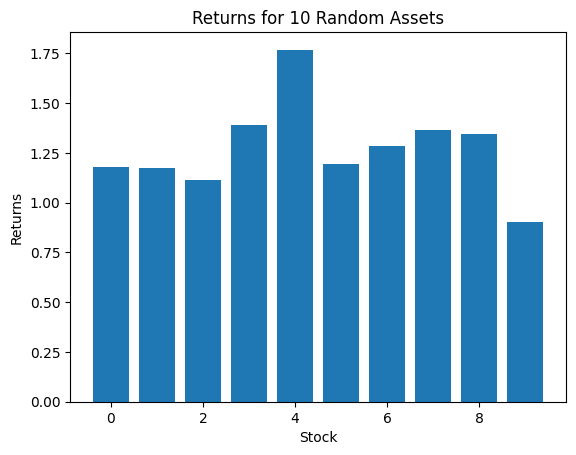

```python
plt.bar(np.arange(len(mean_returns)), mean_returns)
plt.xlabel('Stock')
plt.ylabel('Returns')
plt.title('Returns for {0} Random Assets'.format(N));
```

## Tính Toán Lợi Nhuận Kỳ Vọng

Vậy là chúng ta có một tập hợp các cổ phiếu. Tuyệt vời! Bây giờ hãy kết hợp chúng lại trong một danh mục đầu tư và tính toán lợi nhuận kỳ vọng và rủi ro của nó.

Chúng ta sẽ bắt đầu bằng cách tạo ra $N$ trọng số ngẫu nhiên cho từng tài sản trong danh mục đầu tư của chúng ta.

```python
weights = np.random.uniform(0, 1, N)
weights = weights/np.sum(weights)
```

Chúng ta cần điều chỉnh lại trọng số sao cho tổng của chúng bằng $1$. Chúng ta thực hiện điều này bằng cách chia trọng số theo tổng của tất cả các trọng số. Bước này đảm bảo rằng chúng ta sẽ sử dụng $100\%$ tiền mặt của danh mục đầu tư.

Để tính toán lợi suất trung bình của danh mục đầu tư, chúng ta phải điều chỉnh lợi suất của mỗi tài sản theo trọng số đã chỉ định của nó. Chúng ta có thể lấy từng phần tử của từng mảng và nhân chúng một cách riêng lẻ, nhưng nhanh hơn là sử dụng các phương pháp đại số tuyến tính của NumPy. Hàm mà chúng ta muốn sử dụng là `dot()`. Hàm này sẽ tính toán tích vô hướng giữa hai mảng cho chúng ta. Vì vậy, nếu $v = \left[ 1, 2, 3 \right]$ và $w = \left[4, 5, 6 \right]$, thì:

$$ v \cdot w = 1 \times 4 + 2 \times 5 + 3 \times 6 $$

Đối với một vector một chiều, tích vô hướng sẽ nhân từng phần tử một cách điểm và cộng tất cả các tích lại với nhau! Trong trường hợp của chúng ta, chúng ta có một vector trọng số, $\omega = \left[ \omega_1, \omega_2, \dots \omega_N\right]$ và một vector lợi suất, $\mu = \left[ \mu_1, \mu_2, \dots, \mu_N\right]$. Nếu chúng ta lấy tích vô hướng của hai vector này, chúng ta sẽ có:

$$ \omega \cdot \mu = \omega_1\mu_1 + \omega_2\mu_2 + \dots + \omega_N\mu_N = \mu_P $$

Điều này mang lại tổng lợi suất của tất cả các tài sản được điều chỉnh theo trọng số tương ứng của chúng. Đây là lợi suất kỳ vọng tổng thể của danh mục đầu tư!

```python
p_returns = np.dot(weights, mean_returns)
print("Expected return of the portfolio:", p_returns)
```

```
Expected return of the portfolio: 1.3089762454584524
```

Tính toán lợi nhuận trung bình khá trực quan và không cần quá nhiều giải thích về đại số tuyến tính. Tuy nhiên, tính toán phương sai của danh mục đầu tư của chúng ta yêu cầu một chút kiến thức nền tảng hơn.

### Cảnh giác với giá trị NaN

Hầu hết các trường hợp, các phép tính này sẽ hoạt động mà không gặp vấn đề gì. Tuy nhiên, khi làm việc với dữ liệu thực, chúng ta có nguy cơ gặp phải các giá trị `nan` trong các mảng của mình. Đây là cách mà NumPy thông báo rằng dữ liệu ở đó bị thiếu hoặc không tồn tại. Các giá trị `nan` này có thể dẫn đến lỗi trong các phép tính toán học, vì vậy điều quan trọng là phải nhận thức được liệu mảng của bạn có chứa giá trị `nan` hay không và biết cách loại bỏ chúng.

```python
v = np.array([1, 2, np.nan, 4, 5])
print(v)
```

```
[ 1.  2. nan  4.  5.]
```

Hãy xem điều gì xảy ra khi chúng ta cố gắng tính trung bình của mảng này.

```python
print(np.mean(v))
```

```
nan
```

Rõ ràng, giá trị `nan` có thể ảnh hưởng lớn đến các phép tính của chúng ta. May mắn thay, chúng ta có thể kiểm tra các giá trị `nan` bằng cách sử dụng hàm `isnan()`.

```python
np.isnan(v)
```

```
array([False, False,  True, False, False])
```

Gọi hàm `isnan()` trên một mảng sẽ áp dụng hàm này cho từng giá trị trong mảng, trả về giá trị `True` nếu phần tử là `nan` và `False` nếu phần tử là hợp lệ. Giờ đây, biết rằng mảng của bạn chứa giá trị `nan` là rất tốt, nhưng làm thế nào để chúng ta loại bỏ các giá trị `nan`? Thật tiện lợi, các mảng NumPy có thể được chỉ mục bằng các giá trị boolean (`True` hoặc `False`). Nếu chúng ta sử dụng một mảng boolean để chỉ mục một mảng, chúng ta sẽ loại bỏ tất cả các giá trị của mảng mà đăng ký là `False` theo điều kiện. Chúng ta sử dụng hàm `isnan()` để tạo ra một mảng boolean, gán giá trị `True` cho mọi thứ *không* phải là `nan` và `False` cho các giá trị `nan`, và chúng ta sử dụng điều đó để chỉ mục vào cùng một mảng.

```python
ix = ~np.isnan(v) # the ~ indicates a logical not, inverting the bools
print(v[ix]) # We can also just write v = v[~np.isnan(v)]
```

```
[1. 2. 4. 5.]
```

```python
print(np.mean(v[ix]))
```

```
3.0
```

Có một vài cách rút ngắn cho quy trình này dưới dạng các hàm NumPy được xây dựng đặc biệt để xử lý chúng, chẳng hạn như `nanmean()`.

```python
print(np.nanmean(v))
```

```
3.0
```

Hàm `nanmean()` đơn giản tính toán giá trị trung bình của mảng như thể không có giá trị `nan` nào cả! Còn một số hàm khác tương tự, vì vậy bạn có thể đọc thêm về chúng trong [tài liệu](https://docs.scipy.org/doc/numpy/user/index.html). Những giá trị không xác định này chủ yếu là vấn đề với dữ liệu hơn là đại số tuyến tính, vì vậy thật hữu ích khi có những cách để xử lý chúng.

### Kết luận

Đại số tuyến tính rất phổ biến trong tài chính và nói chung. Ví dụ, việc tính toán các trọng số *tối ưu* theo lý thuyết danh mục hiện đại được thực hiện bằng các kỹ thuật đại số tuyến tính. Các mảng và hàm trong NumPy cho phép chúng ta xử lý những tính toán này một cách trực quan. Để có cái nhìn nhanh về đại số tuyến tính và cách sử dụng NumPy để thực hiện các phép tính ma trận quan trọng hơn, hãy tiếp tục đến phần tiếp theo.

## Tổng quan về đại số tuyến tính

Hãy bắt đầu với một cái nhìn tổng quan cơ bản về đại số tuyến tính. Đại số tuyến tính liên quan đến việc nhân và kết hợp các giá trị số vô hướng và ma trận. Một giá trị số vô hướng chỉ là một số thực mà chúng ta nhân với một mảng. Khi chúng ta thay đổi kích thước một ma trận hoặc mảng bằng cách sử dụng một số vô hướng, chúng ta nhân từng phần tử riêng lẻ của ma trận hoặc mảng đó với số vô hướng.

Một ma trận là một tập hợp các giá trị, thường được biểu diễn bằng một lưới $m \times n$, trong đó $m$ là số hàng và $n$ là số cột. Chiều dài các cạnh $m$ và $n$ không nhất thiết phải khác nhau. Nếu chúng ta có $m = n$, chúng ta gọi đây là một ma trận vuông. Một trường hợp đặc biệt thú vị của ma trận là khi $m = 1$ hoặc $n = 1$. Trong trường hợp này, chúng ta có một trường hợp đặc biệt của ma trận mà chúng ta gọi là vector. Mặc dù có một đối tượng ma trận trong NumPy, chúng ta sẽ thực hiện mọi thứ bằng cách sử dụng các mảng NumPy vì chúng có thể có nhiều chiều hơn $2$. Để phục vụ cho mục đích của phần này, chúng ta sẽ sử dụng ma trận và mảng một cách thay thế.

Chúng ta có thể biểu diễn phương trình ma trận như sau:

$$ y = A\cdot x $$

Trong đó $A$ là một ma trận $m \times n$, $y$ là một vector $m \times 1$, và $x$ là một vector $n \times 1$. Ở phía bên phải của phương trình, chúng ta đang nhân một ma trận với một vector. Điều này cần chút làm rõ hơn, kẻo chúng ta nghĩ rằng có thể nhân bất kỳ ma trận nào với bất kỳ ma trận nào khác.

### Nhân ma trận

Với việc nhân ma trận, thứ tự mà các ma trận được nhân có ý nghĩa (hay nói cách khác là nhân ma trận không có tính chất giao hoán). Nhân một ma trận bên trái với một ma trận khác có thể là hoàn toàn hợp lệ, nhưng nhân bên phải có thể không xác định.

```python
A = np.array([
        [1, 2, 3, 12, 6],
        [4, 5, 6, 15, 20],
        [7, 8, 9, 10, 10]
    ])
B = np.array([
        [4, 4, 2],
        [2, 3, 1],
        [6, 5, 8],
        [9, 9, 9]
    ])
```

Lưu ý rằng các ma trận đã được định nghĩa ở trên, $A$ và $B$, có kích thước khác nhau. $A$ có kích thước $3 \times 5$ và $B$ có kích thước $4 \times 3$. Quy tắc chung về việc cái gì có thể nhân với cái gì và theo thứ tự nào dựa trên kích thước của các ma trận. Cụ thể, số cột của ma trận bên trái phải bằng số hàng của ma trận bên phải. Nói một cách siêu không chính thức, giả sử chúng ta có một ma trận $m \times n$ và một ma trận $p \times q$. Nếu chúng ta nhân ma trận đầu tiên với ma trận thứ hai ở bên phải, chúng ta sẽ có:

$$ (m \times n) \cdot (p \times q) = (m \times q) $$

Vì vậy, sản phẩm thu được có số hàng giống như ma trận bên trái và số cột giống như ma trận bên phải. Hạn chế này của phép nhân ma trận liên quan đến kích thước là điều quan trọng cần theo dõi khi viết code. Để minh họa điều này, chúng ta sử dụng hàm `dot()` để nhân các ma trận của chúng ta dưới đây:

```python
print(np.dot(A, B))
```

```
---------------------------------------------------------------------------
ValueError                                Traceback (most recent call last)
<ipython-input-31-c4010e250c2c> in <cell line: 0>()
----> 1 print(np.dot(A, B))

ValueError: shapes (3,5) and (4,3) not aligned: 5 (dim 1) != 4 (dim 0)
```

Các kết quả này phù hợp với quy tắc của chúng ta. Nhân một ma trận $3 \times 5$ ở bên phải với một ma trận $4 \times 3$ sẽ dẫn đến lỗi, trong khi nhân một ma trận $4 \times 3$ ở bên phải với một ma trận $3 \times 5$ sẽ cho ra một ma trận $4 \times 5$.

```python
print(np.dot(B, A))
```

```
[[ 34  44  54 128 124]
 [ 21  27  33  79  82]
 [ 82 101 120 227 216]
 [108 135 162 333 324]]
```

## Phương sai danh mục đầu tư

Hãy quay lại với ví dụ về danh mục đầu tư mà chúng ta đã thảo luận trước đó. Chúng ta đã tính toán lợi suất kỳ vọng của danh mục, nhưng làm thế nào để tính toán phương sai? Chúng ta bắt đầu bằng cách cố gắng đánh giá danh mục đầu tư như một tổng hợp của từng tài sản riêng lẻ, được quy đổi theo trọng số của nó.

$$ VAR[P] = VAR[\omega_1 S_1 + \omega_2 S_2 + \cdots + \omega_N S_N] $$

Trong đó $S_0, \cdots, S_N$ là các tài sản có trong vũ trụ của chúng ta. Nếu tất cả các tài sản của chúng ta đều độc lập với nhau, chúng ta có thể đơn giản đánh giá điều này như sau:

$$ VAR[P] = VAR[\omega_1 S_1] + VAR[\omega_2 S_2] + \cdots + VAR[\omega_N S_N] = \omega_1^2\sigma_1^2 + \omega_2^2\sigma_2^2 + \cdots + \omega_N^2\sigma_N^2 $$

Tuy nhiên, tất cả các tài sản của chúng ta đều phụ thuộc vào nhau bởi cấu trúc của chúng. Chúng đều có liên quan đến tài sản cơ sở của chúng ta và do đó là phụ thuộc nhau. Vì vậy, chúng ta cần tính toán phương sai của danh mục đầu tư bằng cách bao gồm các phương sai cặp riêng lẻ của từng tài sản. Công thức cho phương sai của danh mục đầu tư là:

$$ VAR[P] = \sigma_P^2 = \sum_i \omega_i^2\sigma_i^2 + \sum_i\sum_{i\neq j} \omega_i\omega_j\sigma_i\sigma_j\rho_{i, j}, \ i, j \in \lbrace 1, 2, \cdots, N \rbrace $$

Trong đó $\rho_{i,j}$ là hệ số tương quan giữa $S_i$ và $S_j$, $\rho_{i, j} = \frac{COV[S_i, S_j]}{\sigma_i\sigma_j}$. Điều này có vẻ rất phức tạp, nhưng chúng ta có thể dễ dàng xử lý tất cả điều này bằng cách sử dụng các mảng NumPy. Đầu tiên, chúng ta sẽ tính toán ma trận hiệp phương sai liên quan đến tất cả các cổ phiếu riêng lẻ trong tập vũ trụ của chúng ta.

```python
cov_mat = np.cov(returns)
print(cov_mat)
```

```
[[0.00088654 0.00077346 0.00096645 0.00085609 0.00084569 0.00093687
  0.00094221 0.00084799 0.00081696 0.00091823]
 [0.00077346 0.00104959 0.00083941 0.00072998 0.00079319 0.00073812
  0.00076348 0.00078597 0.00075257 0.00077048]
 [0.00096645 0.00083941 0.00144489 0.00091351 0.00090715 0.00106377
  0.00100633 0.0009373  0.00086776 0.00098828]
 [0.00085609 0.00072998 0.00091351 0.00121235 0.00077078 0.00090809
  0.00088843 0.00085069 0.00079227 0.00091632]
 [0.00084569 0.00079319 0.00090715 0.00077078 0.0011285  0.00091144
  0.00088162 0.00084119 0.00076009 0.00091221]
 [0.00093687 0.00073812 0.00106377 0.00090809 0.00091144 0.00131529
  0.00104044 0.00088125 0.00080229 0.00102536]
 [0.00094221 0.00076348 0.00100633 0.00088843 0.00088162 0.00104044
  0.00133733 0.00093482 0.00086151 0.00103965]
 [0.00084799 0.00078597 0.0009373  0.00085069 0.00084119 0.00088125
  0.00093482 0.00121836 0.00082719 0.00080932]
 [0.00081696 0.00075257 0.00086776 0.00079227 0.00076009 0.00080229
  0.00086151 0.00082719 0.00112402 0.00083066]
 [0.00091823 0.00077048 0.00098828 0.00091632 0.00091221 0.00102536
  0.00103965 0.00080932 0.00083066 0.00124596]]
```

Mảng này trông không được đẹp cho lắm, nhưng ma trận hiệp phương sai là một khái niệm rất quan trọng. Ma trận hiệp phương sai có dạng:

$$ \left[\begin{matrix} VAR[S_1] & COV[S_1, S_2] & \cdots & COV[S_1, S_N] \\ COV[S_2, S_1] & VAR[S_2] & \cdots & COV[S_2, S_N] \\ \vdots & \vdots & \ddots & \vdots \\ COV[S_N, S_1] & COV[S_N, S_2] & \cdots & VAR[S_N] \end{matrix}\right] $$

Vì vậy, mỗi phần tử trên đường chéo là phương sai của tài sản tại chỉ số đó và mỗi phần tử ngoài đường chéo giữ giá trị hiệp phương sai của hai tài sản được chỉ định bởi số cột và số hàng. Điều quan trọng là một khi chúng ta có ma trận hiệp phương sai, chúng ta có thể thực hiện một số phép đại số tuyến tính rất nhanh để tính toán phương sai của toàn bộ danh mục đầu tư. Chúng ta có thể biểu diễn phương sai của danh mục đầu tư dưới dạng mảng như sau:

$$ \sigma_p^2 = \omega \ C \ \omega^\intercal$$

Trong đó $C$ là ma trận hiệp phương sai của tất cả các tài sản và $\omega$ là mảng chứa trọng số của từng tài sản cá nhân. Chỉ số trên $\intercal$ trên $\omega$ thứ hai được nêu ở trên biểu thị cho **ma trận chuyển vị** của $\omega$. Để tham khảo về việc đánh giá phương sai của một danh mục như một phương trình ma trận, vui lòng xem bài viết trên Wikipedia về [lý thuyết danh mục hiện đại](https://en.wikipedia.org/wiki/Modern_portfolio_theory).

Ma trận chuyển vị của một mảng là những gì bạn nhận được khi bạn hoán đổi hàng và cột của một mảng. Điều này có tác dụng phản chiếu một mảng qua điều mà bạn có thể tưởng tượng như một đường chéo. Ví dụ, hãy lấy mảng $A$ mà chúng ta đã đề cập trước đó:

```python
print(A)
```

```
[[ 1  2  3 12  6]
 [ 4  5  6 15 20]
 [ 7  8  9 10 10]]
```

Ma trận chuyển vị đổi hàng thành cột, cột thành hàng:

```python
print(np.transpose(A))
```

```
[[ 1  4  7]
 [ 2  5  8]
 [ 3  6  9]
 [12 15 10]
 [ 6 20 10]]
```

Nhưng $\omega$ ở đây là một mảng 1 chiều, một vector! Thật hợp lý khi lấy chuyển vị của $A$, một mảng $3 \times 5$, vì đầu ra sẽ là một mảng $5 \times 3$, nhưng một mảng 1 chiều không hoàn toàn trực quan như vậy. Một mảng 1 chiều điển hình có thể được coi là một vector nằm ngang $1 \times n$. Do đó, việc lấy chuyển vị của mảng này về cơ bản có nghĩa là chuyển nó thành một vector đứng $n \times 1$. Điều này có lý vì các mảng 1 chiều vẫn là các mảng và bất kỳ phép nhân nào giữa các mảng 1 chiều và các mảng có kích thước lớn hơn phải tuân thủ vấn đề về kích thước trong phép nhân ma trận.

Để nói ngắn gọn, chúng ta coi $\omega$ là $1 \times N$ vì chúng ta có $N$ chứng khoán. Điều này khiến cho $\omega^\intercal$ là $N \times 1$. Một lần nữa, ma trận hiệp phương sai của chúng ta là $N \times N$. Vậy nên, phép nhân tổng thể hoạt động như sau, bằng lời không chính thức:

$$ \text{Kích thước}(\sigma_p^2) = \text{Kích thước}(\omega C \omega^\intercal) = (1 \times N)\cdot (N \times N)\cdot (N \times 1) = (1 \times 1)$$

Nhân ma trận hiệp phương sai bên trái bằng vector ngang thông thường và bên phải bằng chuyển vị của vector đó dẫn đến việc tính toán một giá trị vô hướng duy nhất ($1 \times 1$), phương sai của danh mục đầu tư của chúng ta.

Vì vậy, biết điều này, hãy tiến hành và tính toán phương sai của danh mục đầu tư! Chúng ta có thể dễ dàng tính toán tích của các mảng này bằng cách sử dụng `dot()` cho phép nhân ma trận, mặc dù lần này chúng ta phải làm điều đó hai lần.

```python
# Calculating the portfolio volatility
var_p = np.dot(np.dot(weights, cov_mat), weights.T)
vol_p = np.sqrt(var_p)
print("Portfolio volatility:", vol_p)
```

```
Portfolio volatility: 0.029877931882344146
```

Để xác nhận phép tính này, đơn giản là tính độ biến động của danh mục đầu tư tổng thể bằng cách sử dụng các hàm của NumPy.

```python
# Confirming calculation
vol_p_alt = np.sqrt(np.var(np.dot(weights, returns), ddof=1))
print("Portfolio volatility: ", vol_p_alt)
```

```
Portfolio volatility:  0.029877931882344146
```

Tham số `ddof` là một đầu vào số nguyên đơn giản cho biết số bậc tự do cần tính đến trong hàm. Đây là một khái niệm thống kê, nhưng điều này cho chúng ta biết rằng phép toán ma trận của chúng ta là chính xác!

Nhiều điều trong số này có thể không rõ ràng với trực giác của bạn. Việc quay lại giữa lý thuyết và các biểu diễn code có thể giúp bạn hiểu rõ hơn về phép tính toán học liên quan. Không nhất thiết phải trở thành chuyên gia về đại số tuyến tính và các phép toán ma trận, nhưng đại số tuyến tính có thể giúp làm đơn giản hóa quá trình làm việc với một lượng lớn dữ liệu. Để tìm hiểu thêm về NumPy, hãy xem [tài liệu](https://docs.scipy.org/doc/numpy/user/index.html).

*Lưu ý: Tài liệu này mang tính chất chia sẻ kiến thức khoa học dữ liệu. Các mã chứng khoán xuất hiện trong tài liệu chỉ mang tính chất minh hoạ, không khuyến nghị đầu tư. Chúng tôi không chịu trách nhiệm trước mọi rủi ro nào do sử dụng tài liệu này.*